# Mammary Notebook

Enter the directory of the maca folder on your drive and the name of the tissue you want to analyze.

```r
tissue_of_interest = "Mammary"
```

Load the requisite packages and some additional helper functions.

```r
library(here)
library(useful)
library(Seurat)
library(dplyr)
library(Matrix)
library(ontologyIndex)
cell_ontology = get_ontology('https://raw.githubusercontent.com/obophenotype/cell-ontology/master/cl-basic.obo', extract_tags='everything')
validate_cell_ontology = function(cell_ontology_class){
  in_cell_ontology = sapply(cell_ontology_class, function(x) is.element(x, cell_ontology$name) || is.na(x))
  if (!all(in_cell_ontology)) {
    message = paste0('"', cell_ontology_class[!in_cell_ontology], '" is not in the cell ontology
')
    stop(message)
  }
}
convert_to_cell_ontology_id = function(cell_ontology_class){
  return(sapply(cell_ontology_class, function(x) as.vector(cell_ontology$id[cell_ontology$name == x])[1]))
}
save_dir = here('00_data_ingest', '04_tissue_robj_generated')
```

```r
# read the metadata to get the plates we want
droplet_metadata_filename = here('00_data_ingest', '01_droplet_raw_data', 'metadata_droplet.csv')
droplet_metadata <- read.csv(droplet_metadata_filename, sep=",", header = TRUE)
colnames(droplet_metadata)[1] <- "channel"
droplet_metadata
```

| channel | mouse.id | tissue | subtissue | mouse.sex |
| --- | --- | --- | --- | --- |
| 10X_P4_0 | 3-M-8 | Tongue | NA | M |
| 10X_P4_1 | 3-M-9 | Tongue | NA | M |
| 10X_P4_2 | 3-M-8/9 | Liver | hepatocytes | M |
| 10X_P4_3 | 3-M-8 | Bladder | NA | M |
| 10X_P4_4 | 3-M-9 | Bladder | NA | M |
| 10X_P4_5 | 3-M-8 | Kidney | NA | M |
| 10X_P4_6 | 3-M-9 | Kidney | NA | M |
| 10X_P4_7 | 3-M-8 | Spleen | NA | M |
| 10X_P7_0 | 3-F-56 | Liver | NA | F |
| 10X_P7_1 | 3-F-57 | Liver | NA | F |

[output cut: 18 more lines]

Subset the metadata on the tissue.

```r
tissue_metadata = filter(droplet_metadata, tissue == tissue_of_interest)[,c('channel','tissue','subtissue','mouse.sex')]
tissue_metadata
```

| channel | tissue | subtissue | mouse.sex |
| --- | --- | --- | --- |
| 10X_P7_12 | Mammary | NA | F |
| 10X_P7_13 | Mammary | NA | F |

Use only the metadata rows corresponding to plates of this tissue. Make a plate barcode dataframe to “expand” the per-plate metadata to be per-cell.

```r
# Load the gene names and set the metadata columns by opening the first file
subfolder = paste0(tissue_of_interest, '-', tissue_metadata$channel[1])
raw.data <- Read10X(data.dir = here('00_data_ingest', '01_droplet_raw_data', 'droplet', subfolder))
colnames(raw.data) <- lapply(colnames(raw.data), function(x) paste0(tissue_metadata$channel[1], '_', x))
meta.data = data.frame(row.names = colnames(raw.data))
meta.data['channel'] = tissue_metadata$channel[1]
if (length(tissue_metadata$channel) > 1){
  # Some tissues, like Thymus and Heart had only one channel
  for(i in 2:nrow(tissue_metadata)){
    subfolder = paste0(tissue_of_interest, '-', tissue_metadata$channel[i])
    new.data <- Read10X(data.dir = here('00_data_ingest', '01_droplet_raw_data', 'droplet', subfolder))
    colnames(new.data) <- lapply(colnames(new.data), function(x) paste0(tissue_metadata$channel[i], '_', x))

    new.metadata = data.frame(row.names = colnames(new.data))
    new.metadata['channel'] = tissue_metadata$channel[i]

    raw.data = cbind(raw.data, new.data)
    meta.data = rbind(meta.data, new.metadata)
  }
}
rnames = row.names(meta.data)
meta.data <- merge(meta.data, tissue_metadata, sort = F)
row.names(meta.data) <- rnames
dim(raw.data)
```

```
[1] 23433  4481
```

```r
corner(raw.data)
```

```
[1] 0 0 0 0 0
```

```r
head(meta.data)
```

|  | channel | tissue | subtissue | mouse.sex |
| --- | --- | --- | --- | --- |
| 10X_P7_12_AAACCTGAGTTGAGAT | 10X_P7_12 | Mammary | NA | F |
| 10X_P7_12_AAACCTGTCGTCACGG | 10X_P7_12 | Mammary | NA | F |
| 10X_P7_12_AAACCTGTCTTGTACT | 10X_P7_12 | Mammary | NA | F |
| 10X_P7_12_AAACCTGTCTTTAGTC | 10X_P7_12 | Mammary | NA | F |
| 10X_P7_12_AAACGGGCAGTGGGAT | 10X_P7_12 | Mammary | NA | F |
| 10X_P7_12_AAACGGGGTAAGTGTA | 10X_P7_12 | Mammary | NA | F |

Order the cells alphabetically to ensure consistency.

```r
ordered_cell_names = order(colnames(raw.data))
raw.data = raw.data[,ordered_cell_names]
meta.data = meta.data[ordered_cell_names,]
corner(raw.data)
```

```
[1] 0 0 0 0 0
```

```r
head(meta.data)
```

|  | channel | tissue | subtissue | mouse.sex |
| --- | --- | --- | --- | --- |
| 10X_P7_12_AAACCTGAGTTGAGAT | 10X_P7_12 | Mammary | NA | F |
| 10X_P7_12_AAACCTGTCGTCACGG | 10X_P7_12 | Mammary | NA | F |
| 10X_P7_12_AAACCTGTCTTGTACT | 10X_P7_12 | Mammary | NA | F |
| 10X_P7_12_AAACCTGTCTTTAGTC | 10X_P7_12 | Mammary | NA | F |
| 10X_P7_12_AAACGGGCAGTGGGAT | 10X_P7_12 | Mammary | NA | F |
| 10X_P7_12_AAACGGGGTAAGTGTA | 10X_P7_12 | Mammary | NA | F |

Process the raw data and load it into the Seurat object.

```r
# Find ERCC's, compute the percent ERCC, and drop them from the raw data.
erccs <- grep(pattern = "^ERCC-", x = rownames(x = raw.data), value = TRUE)
percent.ercc <- Matrix::colSums(raw.data[erccs, ])/Matrix::colSums(raw.data)
ercc.index <- grep(pattern = "^ERCC-", x = rownames(x = raw.data), value = FALSE)
raw.data <- raw.data[-ercc.index,]
# Create the Seurat object with all the data
tiss <- CreateSeuratObject(raw.data = raw.data, project = tissue_of_interest,
                    min.cells = 1, min.genes = 0)
# Continue from here onwards !
tiss <- AddMetaData(object = tiss, meta.data)
tiss <- AddMetaData(object = tiss, percent.ercc, col.name = "percent.ercc")
# Change default name for sums of counts from nUMI to nReads
# colnames(tiss@meta.data)[colnames(tiss@meta.data) == 'nUMI'] <- 'nReads'
# Create metadata columns for cell_ontology_classs and subcell_ontology_classs
tiss@meta.data[,'cell_ontology_class'] <- NA
tiss@meta.data[,'subcell_ontology_class'] <- NA
```

Calculate percent ribosomal genes.

```r
ribo.genes <- grep(pattern = "^Rp[sl][[:digit:]]", x = rownames(x = tiss@data), value = TRUE)
percent.ribo <- Matrix::colSums(tiss@raw.data[ribo.genes, ])/Matrix::colSums(tiss@raw.data)
tiss <- AddMetaData(object = tiss, metadata = percent.ribo, col.name = "percent.ribo")
```

A sanity check: genes per cell vs reads per cell.

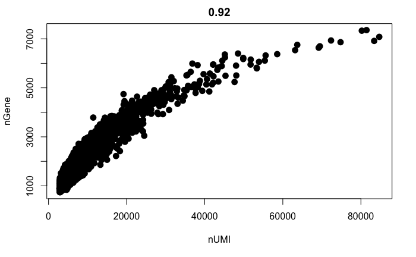

```r
GenePlot(object = tiss, gene1 = "nUMI", gene2 = "nGene", use.raw=T)
```

Filter out cells with few reads and few genes.

```r
tiss <- FilterCells(object = tiss, subset.names = c("nGene", "nUMI"), low.thresholds = c(500, 1000))
```

Normalize the data, then center and scale.

```r
tiss <- NormalizeData(object = tiss, scale.factor = 1e4)
```

```
|----|----|----|----|----|----|----|----|----|----|
```

```r
tiss <- ScaleData(object = tiss)
```

```
[1] "Scaling data matrix"
```

```
|----|----|----|----|----|----|----|----|----|----|
|----|----|----|----|----|----|----|----|----|----|
```

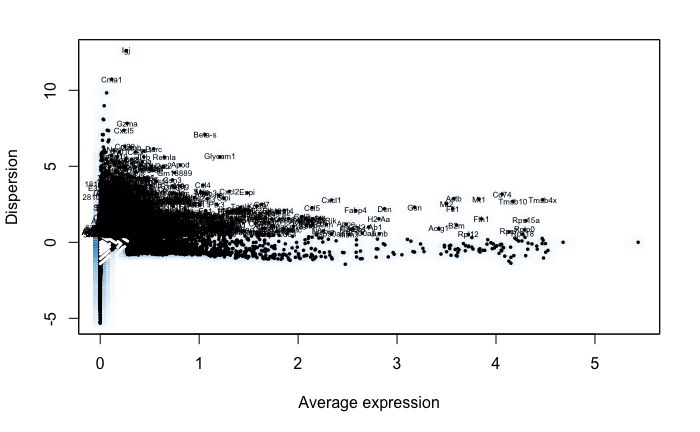

```r
tiss <- FindVariableGenes(object = tiss, do.plot = TRUE, x.high.cutoff = Inf, y.cutoff = 0.5)
```

Run Principal Component Analysis.

```r
tiss <- RunPCA(object = tiss, do.print = FALSE)
tiss <- ProjectPCA(object = tiss, do.print = FALSE)
```

[figure not shown]

Later on (in FindClusters and TSNE) you will pick a number of principal components to use. This has the effect of keeping the major directions of variation in the data and, ideally, supressing noise. There is no correct answer to the number to use, but a decent rule of thumb is to go until the plot plateaus.

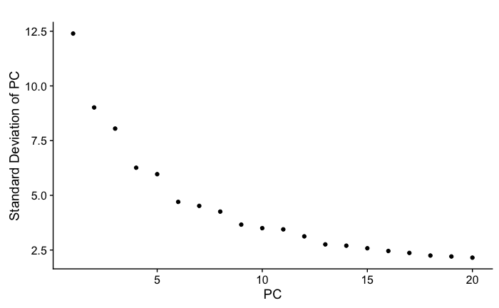

```r
PCElbowPlot(object = tiss)
```

Choose the number of principal components to use.

```r
# Set number of principal components.
n.pcs = 15
```

The clustering is performed based on a nearest neighbors graph. Cells that have similar expression will be joined together. The Louvain algorithm looks for groups of cells with high modularity–more connections within the group than between groups. The resolution parameter determines the scale. Higher resolution will give more clusters, lower resolution will give fewer.

For the top-level clustering, aim to under-cluster instead of over-cluster. It will be easy to subset groups and further analyze them below.

```r
tiss <- FindClusters(object = tiss, reduction.type = "pca", dims.use = 1:n.pcs,
    resolution = res.used, print.output = 0, save.SNN = TRUE)
```

```
Build parameters exactly match those of already computed and stored SNN. To force recalculation, set force.recalc to TRUE.Clustering parameters for resolution 1 exactly match those of already computed.
  To force recalculation, set force.recalc to TRUE.
```

We use TSNE solely to visualize the data.

```r
# If cells are too spread out, you can raise the perplexity. If you have few cells, try a lower perplexity (but never less than 10).
tiss <- RunTSNE(object = tiss, dims.use = 1:n.pcs, seed.use = 10, perplexity=30)
```

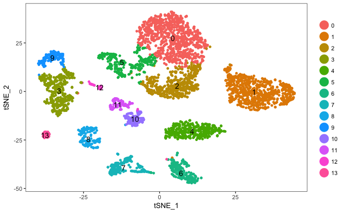

Dotplots let you see the intensity of exppression and the fraction of cells expressing for each of your genes of interest. The radius shows you the percent of cells in that cluster with at least one read sequenced from that gene. The color level indicates the average Z-score of gene expression for cells in that cluster, where the scaling is done over taken over all cells in the sample.

[figure not shown]

[figure not shown]

```r
VlnPlot(tiss, "Myf5", use.raw= T, nCol = 2)
```

We can also find all differentially expressed genes marking each cluster. This may take some time.

```r
#clust.markers0 <- FindMarkers(object = tiss, ident.1 = 0, only.pos = TRUE, min.pct = 0.25, thresh.use = 0.25)
#tiss.markers <- FindAllMarkers(object = tiss, only.pos = TRUE, min.pct = 0.25, thresh.use = 0.25)
```

Display the top markers you computed above.

```r
#tiss.markers %>% group_by(cluster) %>% top_n(5, avg_diff)
```

Using the markers above, we can confidentaly label many of the clusters.

```r
tiss <- StashIdent(object = tiss, save.name = "cluster.ids")
cluster.ids <- c(0, 1, 2, 3, 4, 5, 6, 7, 8, 9, 10, 11, 12, 13)
free_annotation <-
  c(
    "T cell",
    "B cell",
    "T cell",
    "stromal cell",
    "basal cell",
    "T cell",
    "luminal progenitor cell",
    "mature luminal cell",
    "macrophage",
    "stromal cell",
    "endothelial cell",
    "endothelial cell",
    "stromal cell",
    "stromal cell")
cell_ontology_class <-
  c(
    "T cell",
    "B cell",
    "T cell",
    "stromal cell",
    "basal cell",
    "T cell",
    "luminal epithelial cell of mammary gland",
    "luminal epithelial cell of mammary gland",
    "macrophage",
    "stromal cell",
    "endothelial cell",
    "endothelial cell",
    "stromal cell",
    "stromal cell")
tiss@meta.data['free_annotation'] <- as.character(plyr::mapvalues(x = tiss@ident, from = cluster.ids, to = free_annotation))
validate_cell_ontology(cell_ontology_class)
cell_ontology_id = convert_to_cell_ontology_id(cell_ontology_class)
tiss@meta.data[,'free_annotation'] <- plyr::mapvalues(x = tiss@ident, from = cluster.ids, to = free_annotation)
tiss@meta.data[,'cell_ontology_class'] <- plyr::mapvalues(x = tiss@ident, from = cluster.ids, to = cell_ontology_class)
tiss@meta.data[,'cell_ontology_id'] <- plyr::mapvalues(x = tiss@ident, from = cluster.ids, to = cell_ontology_id)
```

## Checking for batch effects

Color by metadata, like plate barcode, to check for batch effects.

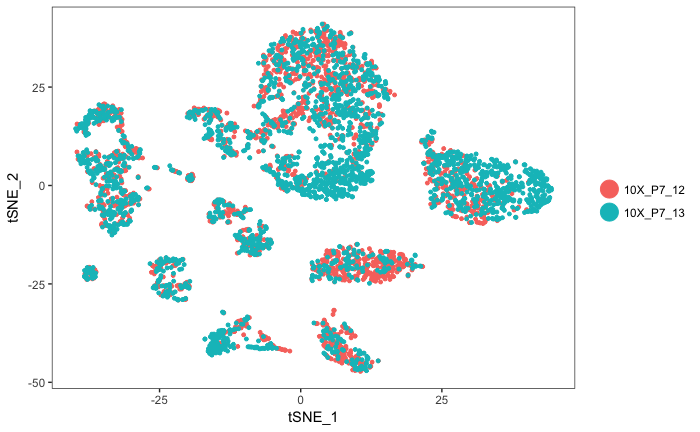

# Final coloring

Color by cell ontology class on the original TSNE.

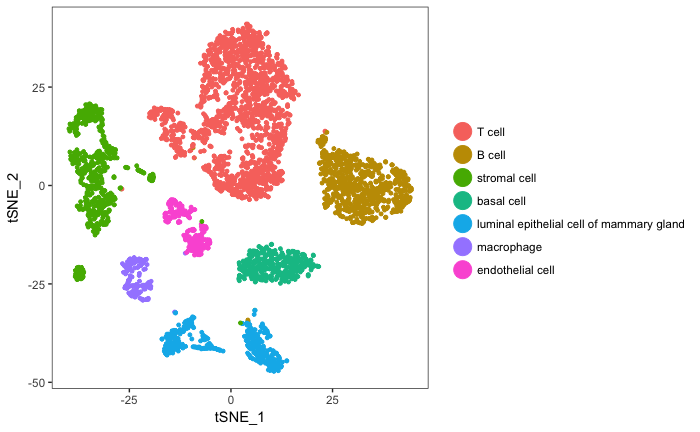

# Save the Robject for later

```r
filename = here('00_data_ingest', '04_tissue_robj_generated',
                     paste0("facs_", tissue_of_interest, "_seurat_tiss.Robj"))
print(filename)
```

```
[1] "/Users/shaheen/Documents/GitHub/tabula-muris/00_data_ingest/04_tissue_robj_generated/facs_Mammary_seurat_tiss.Robj"
```

```r
save(tiss, file=filename)
```

```r
# To reload a saved object
# filename = here('00_data_ingest', '04_tissue_robj_generated',
#                      paste0("facs", tissue_of_interest, "_seurat_tiss.Robj"))
# load(file=filename)
```

# Export the final metadata

So that Biohub can easily combine all your cell_ontology_classs, please export them as a simple csv.

```r
head(tiss@meta.data)
```

```r
filename = here('00_data_ingest', '03_tissue_annotation_csv',
                     paste0(tissue_of_interest, "_droplet_annotation.csv"))
write.csv(FetchData(tiss, c('channel','cell_ontology_class','cell_ontology_id', 'free_annotation', 'tSNE_1', 'tSNE_2')), file=filename)
```